# 🧠 A História da Linguagem Python

## 👤 O que é uma linguagem de programação

Programação é o processo de analisar uma tarefa, dividi-la em pedaços ou etapas e escrever uma sequência de instruções que o computador possa entender e executar

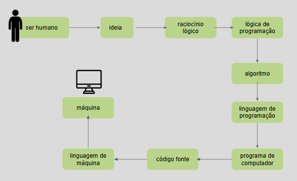

- **Ser Humano:** Tudo começa com nós, humanos, que temos uma ideia a resolver — um problema, uma tarefa, um processo a automatizar.
- **Ideia**: A ideia é o ponto de partida abstrato. Exemplo: “Quero um programa que calcule a média de três notas.”
- **Raciocínio Lógico**: Para transformar a ideia em algo que o computador possa entender, precisamos organizar o pensamento de forma lógica. Aqui entram: Condições (if/else),Repetições (loops), Etapas sequenciais (passo a passo)
- **Lógica de Programação**: A lógica de programação é a estrutura mental que permite converter raciocínio em instruções organizadas. É o alicerce da programação. É aqui que entram os paradigmas, como veremos.
- **Algoritmo**: Um algoritmo é a descrição ordenada, clara e finita dos passos necessários para resolver um problema.
- **Linguagem de Programação**: Agora, o algoritmo é traduzido para uma linguagem que o computador consiga interpretar — como Python, JavaScript, C++, etc. Essas linguagens têm: Sintaxe (como escrever), Semântica (como interpretar)e Regras próprias.
- **Programa de Computador**: O código escrito na linguagem de programação forma o programa, ou seja, o conjunto de instruções que executam uma função específica.
- **Código Fonte**: O que escrevemos é o código fonte: um arquivo legível por humanos, mas incompreensível pela máquina em sua forma bruta.
- **Linguagem de Máquina**: O código fonte precisa ser convertido para linguagem de máquina (binária: 0s e 1s) para que o computador possa executá-lo. Essa conversão pode ocorrer de duas formas: Por um compilador (ex: C) ou Por um interpretador (ex: Python).
- **Máquina**: Por fim, a máquina executa o programa — obedecendo às instruções binárias resultantes — e realiza a tarefa solicitada (exibir a média, somar dados, gerar um gráfico, etc).

> Compreender esse fluxo ajuda a perceber que programar é mais do que escrever código — é uma forma estruturada de transformar pensamento em ação concreta via tecnologia.

OBS: A diferença entre Compilação e Interpretação é uma das diferenças mais fundamentais entre linguagens de programação: como o código fonte é transformado em algo que a máquina pode executar. Isso envolve dois processos: compilação e interpretação.

| Característica | Compilador | Interpretador |
| --- | --- | --- |
| Forma de execução | Compila tudo antes | Executa linha por linha |
| Gera executável? | Sim | Não |
| Velocidade de execução | Alta | Menor |
| Flexibilidade para testes | Menor | Maior |
| Necessidade do código | Não após compilado | Sempre necessário |
| Exemplos | C, C++, Go | Python, JavaScript, R |

## 🔎 Tipos de Linguagens e Onde o Python se situa

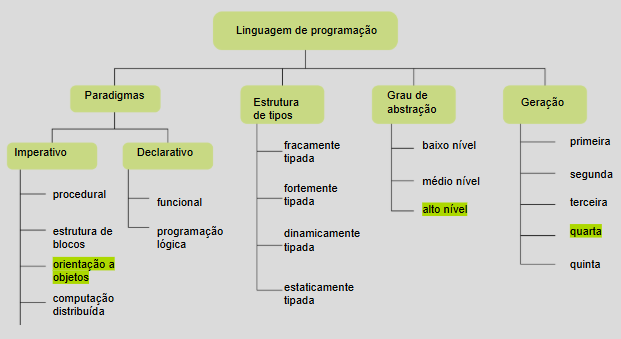

As linguagens de programação podem ser classificadas conforme vários critérios.

#### 🟩 **Paradigmas de Programação**

Um paradigma é um estilo ou modelo de organização do raciocínio computacional. Eles não são mutuamente excludentes.

> Muitas linguagens (como o Python) suportam múltiplos paradigmas.
- Imperativo: Nesse caso, você diz como o programa deve fazer algo, passo a passo. Características: Baseado em comandos e mudanças de estado. Usa estruturas como if, for, while, variáveis mutáveis. É como uma receita de bolo

```python
# @title
# Python é uma linguagem imperativa por padrão.

x = 10
x = x + 5
print(x)
```

```
15
```

- Procedural (subparadigma do imperativo): Nesse caso, Organiza o código em funções/procedimentos reutilizáveis. Características: Ênfase na modularização, Evita repetição de código, Separação clara entre dados e procedimentos

```python
# Python dá suporte completo à programação procedural.

def saudacao(nome):
    print(f"Olá, {nome}!")

saudacao("Gregório")
```

```
Olá, Gregório!
```

- Orientado a Objetos (OO): Modela o mundo em objetos com atributos e comportamentos. Características: Dados e funções encapsulados em classes, Reutilização com herança, polimorfismo, Ideal para modelar entidades complexas (pacientes, pedidos, sensores)

```python
# Python é orientado a objetos desde sua base: tudo é objeto (strings, funções, números, etc).

class Paciente: # Essa linha cria uma classe chamada Paciente. Classe é uma fábrica de objetos: um molde que define como os objetos do tipo Paciente vão se comportar.

    def __init__(self, nome): # É uma função especial do Python que inicializa o objeto.
        self.nome = nome # É uma referência ao próprio objeto que está sendo criado (como o "eu" do objeto). Nome é um parâmetro externo recebido no momento da criação do paciente.

    def cumprimentar(self): # Esse é um método da classe — uma função que pertence à classe Paciente.
        print(f"Olá, sou {self.nome}") # Quando você chama esse método, ele acessa os dados do próprio objeto (como self.nome) e executa uma ação.


p = Paciente("João") # Essa linha cria um novo objeto do tipo Paciente, passando "João" como argumento.
p.cumprimentar() # Aqui, chamamos o método cumprimentar do objeto p.
```

[output not shown]

- Funcional: Foca em funções puras, imutabilidade e ausência de efeitos colaterais. Características: Usa map, filter, reduce, recursão. Funções como valores (funções que recebem e retornam funções). Menor mutação de estado → código mais previsível

```python
# Python não é funcional puro, mas tem suporte funcional suficiente para muitos usos.

dobro = lambda x: x * 2
print(list(map(dobro, [1, 2, 3, 4])))
```

[output not shown]

- Paradigma Declarativo: No paradigma declarativo, você descreve o que deseja obter, não como isso deve ser feito. O foco está no resultado, não nos passos.

```python
# SQL é declarativo. Você só diz o que quer — os dados. Não especifica como percorrer os registros.

'SELECT nome FROM pacientes WHERE idade > 60'
```

```python
# Em Python você precisa, normalmente: Explicitar o controle de fluxo. Mas é possível simular o estilo declarativo, como na biblioteca Pandas:

"df[df['idade'] > 60]['nome']"
```

#### 🟩 **Estrutura de Tipos**

A estrutura de tipos define como a linguagem lida com os tipos de dados (como int, str, bool, etc).

| Tipo | Significado |
| --- | --- |
| **Estática** | O tipo é definido **antes da execução**, geralmente no código fonte. Ex: C, Java. |
| **Dinâmica** | O tipo é definido **em tempo de execução**, baseado no valor atribuído. Ex: Python, JavaScript. |
| **Fortemente tipada** | Impede operações implícitas entre tipos incompatíveis. Ex: Python, Java. |
| **Fracamente tipada** | Permite misturas arriscadas, fazendo conversões automáticas. Ex: JavaScript, C. |

Python tem tipagem Dinâmica (não precisa declarar tipo). E é Fortemente tipada (não converte automaticamente).

```python
x = 10       # tipo int
x = "dez"    # agora é string

print(x + 1) # Erro! Não mistura string com int automaticamente
```

#### 🟩 **Grau de Abstração**

Esse eixo classifica as linguagens com base na distância entre o código e a máquina.

| Grau | Características | Exemplo |
| --- | --- | --- |
| **Baixo nível** | Próxima da linguagem de máquina | Assembly, C |
| **Médio nível** | Mistura instruções mais abstratas com controle de memória | C++, Rust |
| **Alto nível** | Próxima da linguagem humana, abstrai a máquina | Python, JavaScript, Ruby |

Python é uma linguagem de alto nível:

- Abstrai totalmente a memória
- Não usa ponteiros
- Foca em clareza e legibilidade
- Permite escrever menos código para fazer mais

#### 🟩 **Geração da Linguagem**

A classificação por gerações é histórica e representa a evolução da linguagem de máquina para linguagens mais expressivas.

| Geração | Características | Exemplo |
| --- | --- | --- |
| 1ª Geração | Código de máquina binário (0 e 1) | Instruções nativas |
| 2ª Geração | Assembly, usa mnemônicos para instruções | MOV, ADD |
| 3ª Geração | Linguagens estruturadas e imperativas | C, Java |
| 4ª Geração | Linguagens voltadas à produtividade, mais declarativas | SQL, Python, MATLAB |
| 5ª Geração | Foco em IA e lógica (baseadas em inferência) | Prolog, Mercury |

Python é tradicionalmente considerado uma linguagem de 3ª geração, mas por sua:

- Alta expressividade
- Sintaxe próxima da linguagem natural
- Foco em produtividade

É frequentemente considerada também uma linguagem de 4ª geração moderna.

## 🐍 Curiosidade

Você sabia que o Python não tem nada a ver com a cobra?

O nome vem de um grupo de comédia britânico chamado “Monty Python” (https://pt.wikipedia.org/wiki/Monty_Python), do qual o criador da linguagem, Guido van Rossum, era fã. Ele queria um nome que fosse curto, único e um pouco divertido — e conseguiu!

[figure not shown]

## 🕰️ Onde e quando surgiu?

No final dos anos 1980, na Holanda 🇳🇱, Guido estava trabalhando no centro de pesquisa CWI e queria criar uma linguagem de programação que fosse:

- Mais simples de escrever do que C ou Java
- Fácil de entender (até por quem nunca programou)
- Aberta e acessível a todos

Ele lançou a primeira versão oficial do Python em 1991.

[figure not shown]

**Site:** https://www.python.org/

## 🧘 Princípios: O Zen do Python (The Zen of Python)

São 19 princípios escritos por Tim Peters, um dos contribuidores da linguagem

- Beautiful is better than ugly (Belo é melhor que feio.)
- Explicit is better than implicit (Explícito é melhor que implícito.)
- Simple is better than complex (Simples é melhor que complexo.)
- Complex is better than complicated (Complexo é melhor que complicado.)
- Flat is better than nested (Plano é melhor que aninhado.)
- Sparse is better than dense (Espaçado é melhor que denso.)
- Readability counts (Legibilidade conta.)
- Special cases aren't special enough to break the rules. (Casos especiais não são especiais o suficiente para quebrar as regras.)
- Although practicality beats purity (Embora a praticidade vença a pureza.)Errors should never pass silently (Erros nunca devem passar silenciosamente.) Unless explicitly silenced (A não ser que sejam explicitamente silenciados.)
- In the face of ambiguity, refuse the temptation to guess (Diante da ambiguidade, recuse a tentação de adivinhar.)
- There should be one-- and preferably only one --obvious way to do it (Deve haver uma — e preferencialmente apenas uma — maneira óbvia de fazer algo.)
- Although that way may not be obvious at first unless you're Dutch. (Embora essa maneira possa não ser óbvia de início — a menos que você seja holandês.)
- Now is better than never (Agora é melhor do que nunca.)
- Although never is often better than right now. (Embora nunca seja frequentemente melhor do que agora.) If the implementation is hard to explain, it's a bad idea (Se a implementação for difícil de explicar, é uma má ideia.)
- If the implementation is easy to explain, it may be a good idea (Se a implementação for fácil de explicar, pode ser uma boa ideia.)
- Namespaces are one honking great idea -- let's do more of those! (Namespaces são uma grande ideia — vamos usá-los mais!)

```python
#Você pode até vê-los digitando import this dentro de um terminal ou notebook Python!
```

```python
import this
```

```
The Zen of Python, by Tim Peters

Beautiful is better than ugly.
Explicit is better than implicit.
Simple is better than complex.
Complex is better than complicated.
Flat is better than nested.
Sparse is better than dense.
Readability counts.
Special cases aren't special enough to break the rules.
Although practicality beats purity.
Errors should never pass silently.
Unless explicitly silenced.
In the face of ambiguity, refuse the temptation to guess.
There should be one-- and preferably only one --obvious way to do it.
Although that way may not be obvious at first unless you're Dutch.
Now is better than never.
Although never is often better than *right* now.
If the implementation is hard to explain, it's a bad idea.
If the implementation is easy to explain, it may be a good idea.
Namespaces are one honking great idea -- let's do more of those!
```

**Peculariades do Python:**

- Números decimais são representados com ponto: Python foi criado em inglês e, portanto, existem algumas diferenças importantes! Os comandos são escritos em inglês, e também os números (as casas decimais são representadas por um ponto, por exemplo 3.4)
- Letras maiúsculas e minúsculas são diferentes: para a linguagem, "A" é diferente de "a". Essa peculiridade dá a Python a característica de 'case-sensitive'.
- Runtime type: existe mais de uma versão de linguagem Python, e a mais usada atualmente é a Python 3. Acontece que no Colaboratory, o runtime pré-estipulado é o Python 2. Nesse primeiro momento, não há necessidade de entender bem o que significa runtime e essas diferentes versões (ufa!), mas é importante que você faça o seguinte: Clica lá em cima em Runtime. Em seguida, selecione a última opção que vai aparecer, Change runtime type. Por fim, onde tem "Python 2" troque para "Python 3". Clique em save. E pronto! Podemos seguir adiante.

## 🚀 Por que o Python cresceu tanto?

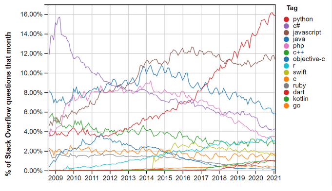

- Simples, legível, poderoso.
- É open source
- Comunidade ativa e vasta documentação
- Amada por iniciantes
- Usada por grandes empresas como Google, Netflix, NASA e Spotify.
- Virou a linguagem preferida para Ciência de Dados, Inteligência Artificial e Automação.

**Bibliotecas**

- Uma biblioteca em Python é uma coleção de módulos que contêm funções, classes e outros objetos que podem ser reutilizados.
- As bibliotecas ajudam a organizar o código e a torná-lo mais fácil de usar e compartilhar.
- Elas estendem a funcionalidade básica do Python, oferecendo ferramentas para tarefas específicas, como manipulação de dados (pandas), computação numérica (numpy), visualização (matplotlib), aprendizado de máquina (scikit-learn), etc.

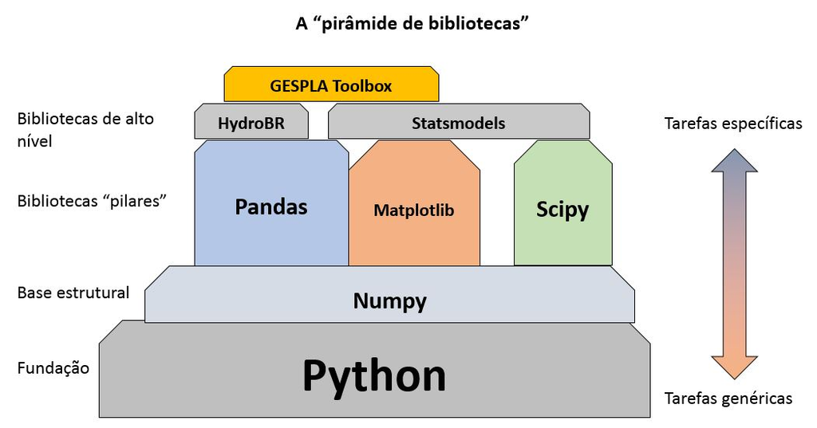